### Unit 5: Spatial

#### Lesson 3: AIS ship tracks

#### New functions: sf::st_crop(),

Automatic Identification System (AIS) is an automatic tracking system that uses tranceivers on vessels to detect their location in space and time. AIS is used secondarily to radar to avoid vessel collisions. Large vessels and passenger ships are required to use AIS. The US Bureau of Ocean Energy Management (BOEM) and NOAA provide AIS data collected by the US Coast Guard for free at https://marinecadastre.gov/AIS/

We can use the AIS data to get a look at the amount of vessel traffic that occurs in the Southeast US North Atlantic right whale critical breeding habitat. Much of this critical habitat has been designated a Seasonal Management Area, where vessels > 65 feet long are required to slow down to < 10 knots during the calving season (from November 15 - April 15 each year). Vessels < 65 feet in length are also encouraged, but not required, to slow down to < 10 knots. NOAA Fisheries issued this ruling to reduce the risk of right whale ship strikes.

Let’s start by loading in the subsetted AIS data, the shapefiles for the right whale critical habitat (that we used earlier) and the world coastline data in R’s `mapdata` package. We will crop the coastline data to the same bounding box that I used when I reduced the size of the original (huge) AIS data.

```r
library(tidyverse)
library(sf)
library(mapdata)
library(marmap)
library(lubridate)
```

```r
## AIS data; Downloaded for January 2017, UTM Zone 17
# https://marinecadastre.gov/AIS/ (not included in data folder bc ~1GB)
# subsetted to 2017-1-25 data with script ais_reduce.R in this repo
ais_day = read.csv('data/processed_ais/ais_2017-01-25.csv')

# Coastline data
lat_bounds = c(25, 34)
lon_bounds = c( -82, -76)
world_map = map_data("worldHires", ylim = lat_bounds, xlim = lon_bounds)
dim(world_map)
```

```
## [1] 62929     6
```

```r
#Read in US critical habitat shapefiles
# https://www.greateratlantic.fisheries.noaa.gov/educational_resources/gis/data/index.html
USA_crit_hab = st_read('data/North_Atlantic_Right_Whale_Critical_Habitat/','North_Atlantic_Right_Whale_Critical_Habitat') # reads in set of shapefiles
USA_crit_hab_sf = st_transform(USA_crit_hab, crs=4326) #crs="+proj=longlat +datum=WGS84")
```

Now let’s plot everything that we loaded up. Note that the AIS data is still quite large, with 119,726 rows. Each row represents a lat/lon coordinate where an AIS signal was emitted. Putting all of these points on a map takes some processing time, but you can significantly speed it up by never actually printing the plot out to the console. Do this by saving the plot to a variable name and using `ggsave()` to write that plot out to a file (like a .pdf, .png or .jpg). Then just open up that file to see your map.

```r
head(ais_day)
```

```
##        MMSI        BaseDateTime      LAT       LON SOG    COG Heading
## 1 319891000 2017-01-25T00:00:03 26.76807 -80.04672 0.3  165.5      54
## 2 235085999 2017-01-25T00:01:11 26.10278 -80.11581 0.0    0.0      90
## 3 367154620 2017-01-25T00:00:01 30.39785 -81.55203 0.0 -168.1     511
## 4 367004750 2017-01-25T00:00:02 29.98081 -81.64696 0.1  166.9     511
## 5 367480180 2017-01-25T00:02:19 25.78630 -80.17944 0.0 -110.2     511
## 6 319093700 2017-01-25T00:00:06 26.06010 -80.13250 0.0   11.7     180
##         VesselName        IMO CallSign VesselType                 Status Length
## 1   LADY KATHRYN V IMO1011068     ZGBK       1019 under way using engine  60.99
## 2     NO BADA BEES IMO9627186    2EKW9       1019 under way using engine  38.90
## 3 GRACE MCALLISTER IMO6823040  WDD5173       1025 under way using engine  35.59
## 4        YBOR CITY IMO7642106  WDI4909       1025 under way using engine  21.49
## 5        GIGA-BYTE             WDF7013       1019 under way using engine  26.61
## 6              RH3 IMO1007861     ZGFN       1019 under way using engine  36.84
##   Width Draft Cargo
## 1 11.41   3.5    NA
## 2  8.20   2.1    37
## 3  9.20   4.7    52
## 4  7.40    NA    52
## 5  6.20    NA    37
## 6  8.30   2.6    NA
```

```r
# plot critical habitats and carcass locations
ais_map_pts = ggplot()+
  geom_polygon(data = world_map, aes(x = long, y = lat, group = group), fill = "black", color = NA) + # add coastline
  geom_sf(data=USA_crit_hab_sf, alpha = 0.5, color=NA, fill='yellow') +
  geom_point(data = ais_day, aes(x = LON, y = LAT, color = CallSign), size=2) +
  coord_sf(1.3, xlim = lon_bounds, ylim = lat_bounds) + # Crop map edges
  guides(color=FALSE) +
  ylab("Latitude") + xlab("Longitude") + theme_classic()

ggsave(ais_map_pts, filename='figures/ais_pts_2017-01-25.pdf', device="pdf", height=5, width=4)
```

Now we’ll do some analysis. First we can use the `ymd_hms()` function in the `lubridate` package to convert the column `BaseDateTime` into a date/time variable (of type `POSIXct`) that R will actually recognize. Then we can simply use the `arrange()` function in dplyr to sort our data by date/time to make sure they are in chronological order. Once that is done, we can group the AIS points by each vessel’s unique `CallSign` and collapse the series of AIS points into ship track lines. Note that arranging the data chronologically and grouping by vessel are critical steps so that the ship tracks make sense.

```r
dim(ais_day)
```

```
## [1] 119726     16
```

```r
ais_day_sf = ais_day %>%
  mutate(date_time = lubridate::ymd_hms(BaseDateTime)) %>%
  arrange(date_time) %>% # ensure ship tracks points are in chronological order
  st_as_sf(coords=c("LON", "LAT"), crs=4326) %>% # '+proj=longlat +datum=WGS84'
  group_by(CallSign, Length) %>% # essentially groups by call sign but retains length (in feet) info
  summarise(do_union=FALSE) %>% # collapses data into multipoint; do_union=FALSE prevents reordering points
  st_cast("LINESTRING")
# class(ais_day_sf$BaseDateTime)
# class(ais_day_sf$date_time) # POSIXct is the date-time class

class(ais_day_sf)
```

```
## [1] "sf"         "grouped_df" "tbl_df"     "tbl"        "data.frame"
```

```r
glimpse(ais_day_sf)
```

```
## Rows: 283
## Columns: 3
## Groups: CallSign [283]
## $ CallSign <fct> 2APT9, 2CWA7, 2EKW9, 3ECR5, 3EDG6, 3EFU3, 3EHF2, 3EOS8, 3EPJ…
## $ Length   <dbl> 126.95, 249.90, 38.90, 242.81, 199.95, 336.67, 336.67, 257.8…
## $ geometry <LINESTRING [°]> LINESTRING (-78.34381 26.30..., LINESTRING (-79.5…
```

```r
dim(ais_day_sf)  # went from 119,726 points to 283 lines !!
```

```
## [1] 283   3
```

After that hard work of collapsing AIS points into sensible ship tracks, let’s plot our results:

```r
# plot ship tracks
ais_day_line_map = ggplot()+
  geom_polygon(data = world_map, aes(x = long, y = lat, group = group), fill = "black", color = NA) + # add coastline
  geom_sf(data=USA_crit_hab_sf, alpha = 0.5, color=NA, fill='yellow') +
  geom_sf(data=ais_day_sf, aes(color=CallSign)) +
  coord_sf(1.3, xlim = lon_bounds, ylim = lat_bounds) + # Crop map edges
  guides(color=FALSE) +
  ylab("Latitude") + xlab("Longitude") + theme_classic()

ggsave(ais_day_line_map, filename='figures/ais_lines_2017-01-25.pdf', device="pdf", height=5, width=4)
```

Now we can see all of the ships that entered this right whale critical habitat during the heart of calving season (January). We can use sf + dplyr packages to ask really simple questions like:

- how many ships entered the critical habitat on 2017-01-25?
- what are the lengths (in feet) of ships that entered the habitat?
- what is the total length (in meters!) of ship tracks within the critical habitat on 2017-01-25?

```r
#########################################################################
#   Compare 2017-01-25 ship tracks with NARW critical habitats
#########################################################################

# library(lwgeom) # where st_make_valid() was originally developed
# Find ship tracks that enter RW habitat with spatial join
ships_RW_join = ais_day_sf %>%
  st_make_valid() %>%
  st_join(USA_crit_hab_sf %>% select(geometry), left=FALSE) # spatial inner join (only keep lines that intersect with polygon)
```

```
## although coordinates are longitude/latitude, st_intersects assumes that they are planar
```

```r
# How many ships went into the RW critical habitat on 2017-1-25?
dim(ships_RW_join)
```

```
## [1] 49  3
```

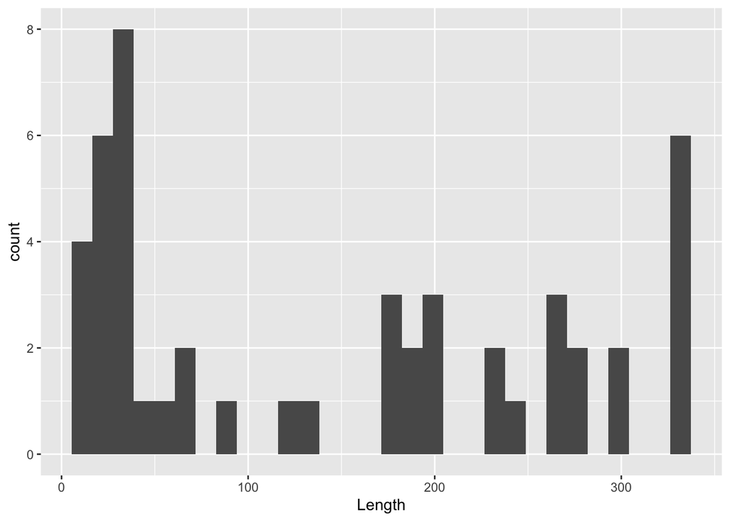

```r
# What are the lengths of the ships that intersected the RW critical habitat?
ggplot() +
  geom_histogram(data=ships_RW_join, aes(x=Length))
```

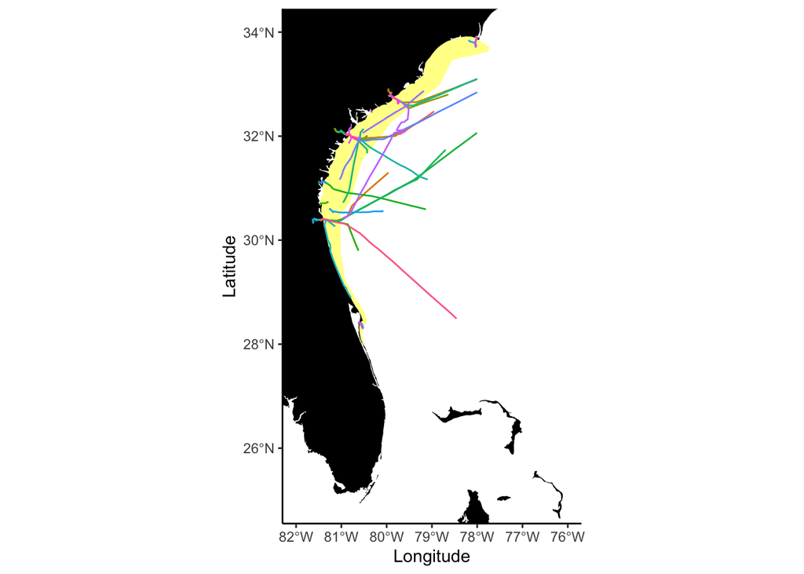

```r
# Plot ship tracks that enter RW habitat
ggplot()+
  geom_polygon(data = world_map, aes(x = long, y = lat, group = group), fill = "black", color = NA) + # add coastline
  geom_sf(data=USA_crit_hab_sf, alpha = 0.5, color=NA, fill='yellow') +
  geom_sf(data=ships_RW_join, aes(color=CallSign)) +
  coord_sf(1.3, xlim = lon_bounds, ylim = lat_bounds) + # Crop map edges
  guides(color=FALSE) +
  ylab("Latitude") + xlab("Longitude") + theme_classic()
```

```r
# Now just grab portions of ship tracks that intersect with RW habitat
ships_RW_intersect = ais_day_sf %>%
  st_make_valid() %>%
  st_intersection(USA_crit_hab_sf %>% select(geometry)) %>%
  mutate(track_length_m = as.numeric(st_length(geometry))) # Calculate length of ship tracks in meters
```

```
## although coordinates are longitude/latitude, st_intersection assumes that they are planar
```

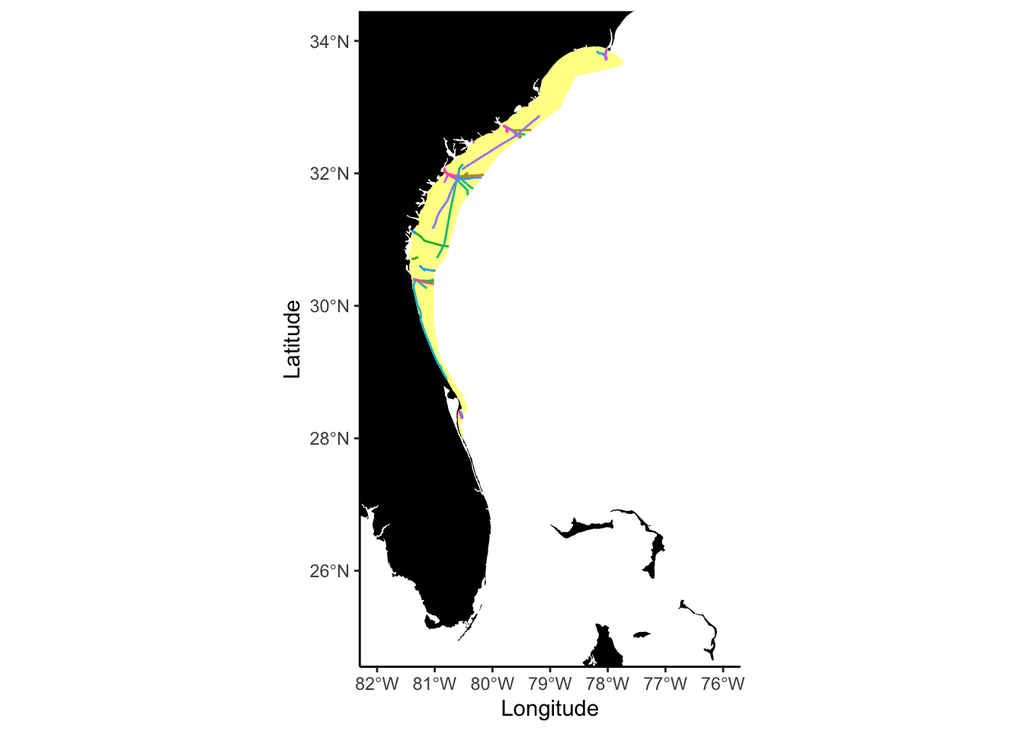

```r
# Plot ship tracks that intersect with RW habitat
ggplot()+
  geom_polygon(data = world_map, aes(x = long, y = lat, group = group), fill = "black", color = NA) + # add coastline
  geom_sf(data=USA_crit_hab_sf, alpha = 0.5, color=NA, fill='yellow') +
  geom_sf(data=ships_RW_intersect, aes(color=CallSign)) +
  coord_sf(1.3, xlim = lon_bounds, ylim = lat_bounds) + # Crop map edges
  guides(color=FALSE) +
  ylab("Latitude") + xlab("Longitude") + theme_classic()
```

```r
# What are the lengths of the ship tracks that intersected the RW critical habitat?
ships_RW_intersect %>%
  summarize(tot_track_length_m = sum(track_length_m)) %>%
  mutate(tot_track_length_km = tot_track_length_m/1000) %>%
  st_drop_geometry()
```

```
## # A tibble: 1 x 2
##   tot_track_length_m tot_track_length_km
## *              <dbl>               <dbl>
## 1           2150861.               2151.
```

You can easily imagine loading the full AIS data set for the month of January 2017 and asking these questions across the whole month. Does the ship traffic change between weekdays and weekends? We could download more data to determine the total vessel traffic across the breeding season (November - April). Grab data from other years - does ship traffic change over time? Are higher vessel traffic years associated with more ship strikes, or calving success? What types of vessels enter the critical habitat? Use AIS data to calculate the vessel speeds. How many vessels are compliant to NOAA’s <10 knot rule? Which vessels are not compliant? Dive into the history of NOAA policy decisions and public education campaigns. Do these efforts correlate with vessel compliance? Research is cool :)